# Infopoints im Überblick Datenstand: 2026-08-10

**Executive Summary**

Datengrundlage / Anzahl an Infopoints

5081 ↑ 0.5%

Analyse-Basis: aktiv & nicht storniert (73.3% der aktiven inkl. storniert)

8177

Infopoints gesamt (alle Projekte inkl. on hold)

6931

In aktiven Projekten — ohne on hold (97 Projekten)

1850

Davon storniert (26.7% der aktiven inkl. storniert)

Infopunkte je Status

1937 ↑ 1.1%

38.1%

receive

1605

31.6%

open

736 ↑ 1%

14.5%

applied for — davon 431 (58.6%) > 12 Wochen offen

463 ↓ 0.2%

9.1%

rejected

324 ↑ 0.3%

6.4%

no response

16 ↓ 11.1%

0.3%

NA / leer

Leitungsrechte

1024 ↑ 0.4%

Gebaut, aber Status ≠ receive (20.2% ohne storniert)

369 ↑ 0.3%

Feeder ohne LR (gesamt)

28

Feeder ohne LR — Planung

157

Feeder ohne LR — im Bau

184

Feeder ohne LR — Bau fertig

229 ↑ 0.4%

Feeder gebaut ohne LR (gesamt)

2

Feeder gebaut ohne LR — Planung

56

Feeder gebaut ohne LR — im Bau

171

Feeder gebaut ohne LR — Bau fertig

Abgeltungen

692

Payment required = Yes (13.6% ohne storniert)

157

Qualifiziert: Built & receive (22.7% der Abgeltungen)

**Note**

Alle Zahlen und Prozentangaben beziehen sich auf **5081 aktive, nicht stornierte Infopoints** in 97 Projekten (ohne on hold). Ausgefiltert: 1850 storniert + 1246 in on hold Projekten. Die Prozentangaben zeigen die Veränderung zur Vorwoche.

**Kapitel 1: Status-Übersicht nach Projekt**

Übersicht aller Infopoints nach Bau/Planung-Status, PB, LR-Akquise und Projekt — aufgeschlüsselt nach den möglichen Status-Werten. Stornierte Infopoints sind hier zur Vollständigkeit mitgezeigt; in allen anderen Kapiteln sind sie ausgeschlossen.

### 1.1 Status-Übersicht nach Projekt

| Bau/Planung | PB | LR-Akquise | Projekt | Leer | open | applied for | receive | rejected | no response | canceled | Gesamt |
| --- | --- | --- | --- | --- | --- | --- | --- | --- | --- | --- | --- |
| Bau fertig | DPB | DPB | 2041901, Maria Wörth | 0 | 48 | 2 | 16 | 11 | 3 | 28 | 108 |
| Bau fertig | Kornfeld | Energiekanzlei | 30401001, Wiener Neustadt 1 | 0 | 9 | 0 | 3 | 3 | 0 | 12 | 27 |
| Bau fertig | Kornfeld | Energiekanzlei | 30401006, Wiener Neustadt 6 | 0 | 0 | 8 | 1 | 1 | 2 | 6 | 18 |
| Bau fertig | Telecs | Telecs | 30612, Günselsdorf | 0 | 10 | 5 | 2 | 2 | 0 | 7 | 26 |
| Bau fertig | ZEIB | ZEIB | 3061601, Klausen-Leopoldsdorf | 0 | 8 | 0 | 1 | 0 | 0 | 0 | 9 |
| Bau fertig | ZEIB | ZEIB | 3061801, Kottingbrunn | 0 | 74 | 0 | 45 | 11 | 4 | 19 | 153 |
| Bau fertig | SPIE KEM | Energiekanzlei | 30639, Traiskirchen-Oeynhausen | 0 | 8 | 0 | 11 | 1 | 0 | 3 | 23 |
| Bau fertig | SPIE KEM | Energiekanzlei | 30639, Traiskirchen-Tribuswinkel | 0 | 0 | 0 | 4 | 2 | 0 | 41 | 47 |
| Bau fertig | ZEIB | ZEIB | 30706, Enzersdorf an der Fischa | 0 | 22 | 0 | 6 | 1 | 0 | 14 | 43 |
| Bau fertig | ZEIB | ZEIB | 3071601, Mannersdorf am Leithagebirge | 0 | 100 | 0 | 1 | 0 | 0 | 0 | 101 |

[output cut: 84 more lines]

⬇ Tabelle (CSV) ⬇ Rohdaten (CSV)

### 1.2 Status und Building Type

**Infopoints nach Status und Building Type**

| Status | Total | Total % | estate | estate % | private road | private road % | NA | NA % | WEG | WEG % | serial house | serial house % |
| --- | --- | --- | --- | --- | --- | --- | --- | --- | --- | --- | --- | --- |
| NA / leer | 16 | 100 | 4 | 25 | 1 | 6.2 | 11 | 68.8 | 0 | 0 | 0 | 0 |
| applied for | 736 | 100 | 332 | 45.1 | 328 | 44.6 | 17 | 2.3 | 9 | 1.2 | 50 | 6.8 |
| no response | 324 | 100 | 217 | 67 | 101 | 31.2 | 0 | 0 | 1 | 0.3 | 5 | 1.5 |
| open | 1605 | 100 | 1212 | 75.5 | 291 | 18.1 | 25 | 1.6 | 4 | 0.2 | 73 | 4.5 |
| receive | 1937 | 100 | 1205 | 62.2 | 622 | 32.1 | 12 | 0.6 | 34 | 1.8 | 64 | 3.3 |
| rejected | 463 | 100 | 235 | 50.8 | 200 | 43.2 | 0 | 0 | 6 | 1.3 | 22 | 4.8 |

⬇ Tabelle (CSV) ⬇ Rohdaten (CSV)

**Warning⚠️ Infopoints ohne Status**

**16 Infopoints** in dieser Tabelle haben keinen Status-Eintrag (`NA / leer`). Diese sollten bereinigt werden.

### 1.3 Status und FeederDrop Level

**Infopoints nach Status und FeederDrop Level**

| Status | Total | Total % | Drop Level | Drop Level % | NA | NA % | Feeder Level | Feeder Level % |
| --- | --- | --- | --- | --- | --- | --- | --- | --- |
| NA / leer | 16 | 100 | 5 | 31.2 | 11 | 68.8 | 0 | 0 |
| applied for | 736 | 100 | 599 | 81.4 | 6 | 0.8 | 131 | 17.8 |
| no response | 324 | 100 | 285 | 88 | 0 | 0 | 39 | 12 |
| open | 1605 | 100 | 1400 | 87.2 | 22 | 1.4 | 183 | 11.4 |
| receive | 1937 | 100 | 1430 | 73.8 | 10 | 0.5 | 497 | 25.7 |
| rejected | 463 | 100 | 445 | 96.1 | 2 | 0.4 | 16 | 3.5 |

⬇ Tabelle (CSV) ⬇ Rohdaten (CSV)

**Warning⚠️ Infopoints ohne Status**

**16 Infopoints** in dieser Tabelle haben keinen Status-Eintrag (`NA / leer`). Diese sollten bereinigt werden.

#### 1.3.1 Fehlende FeederDrop-Informationen nach Projekt

Projekte, bei denen Infopoints keinen FeederDrop Level eingetragen haben (weder Drop Level noch Feeder Level).

**Zusammenfassung nach Planungsbüro (PB):**

**Fehlende FeederDrop-Informationen nach PB**

| PB | Total | Total % | Drop Level | Drop Level % | Feeder Level | Feeder Level % | NA | NA % |
| --- | --- | --- | --- | --- | --- | --- | --- | --- |
| GisQuadrat | 187 | 100 | 171 | 91.4 | 1 | 0.5 | 15 | 8 |
| KPP | 895 | 100 | 699 | 78.1 | 185 | 20.7 | 11 | 1.2 |
| CCE | 221 | 100 | 201 | 91 | 15 | 6.8 | 5 | 2.3 |
| moleplan | 152 | 100 | 116 | 76.3 | 31 | 20.4 | 5 | 3.3 |
| GWK | 982 | 100 | 782 | 79.6 | 196 | 20 | 4 | 0.4 |
| Telecs | 82 | 100 | 76 | 92.7 | 3 | 3.7 | 3 | 3.7 |
| ZEIB | 689 | 100 | 543 | 78.8 | 143 | 20.8 | 3 | 0.4 |
| Kastner | 177 | 100 | 158 | 89.3 | 17 | 9.6 | 2 | 1.1 |
| IKW | 228 | 100 | 193 | 84.6 | 34 | 14.9 | 1 | 0.4 |
| Libra | 48 | 100 | 45 | 93.8 | 2 | 4.2 | 1 | 2.1 |

[output cut: 1 more lines]

⬇ Tabelle (CSV) ⬇ Rohdaten (CSV)

**Aufschlüsselung nach Projekt:**

**Fehlende FeederDrop-Informationen nach Projekt**

| Planned by | PB | Total | Total % | Drop Level | Drop Level % | Feeder Level | Feeder Level % | NA | NA % |
| --- | --- | --- | --- | --- | --- | --- | --- | --- | --- |
| 20630, Radenthein | GisQuadrat | 105 | 100 | 90 | 85.7 | 0 | 0 | 15 | 14.3 |
| 62379, Feldbach | moleplan | 152 | 100 | 116 | 76.3 | 31 | 20.4 | 5 | 3.3 |
| 40201001, Steyr_1 | KPP | 108 | 100 | 100 | 92.6 | 4 | 3.7 | 4 | 3.7 |
| 30612, Günselsdorf | Telecs | 19 | 100 | 16 | 84.2 | 0 | 0 | 3 | 15.8 |
| 40201004, Steyr_4 | KPP | 42 | 100 | 28 | 66.7 | 11 | 26.2 | 3 | 7.1 |
| 20201003, Villach - Untere Fellach | CCE | 48 | 100 | 46 | 95.8 | 0 | 0 | 2 | 4.2 |
| 20201005, Villach - Auen | CCE | 27 | 100 | 24 | 88.9 | 1 | 3.7 | 2 | 7.4 |
| 31327, Mautern an der Donau | ZEIB | 17 | 100 | 15 | 88.2 | 0 | 0 | 2 | 11.8 |
| 61053, Leibnitz – Cluster 1 Süd | GWK | 23 | 100 | 19 | 82.6 | 2 | 8.7 | 2 | 8.7 |
| 6211501, Krieglach | KPP | 63 | 100 | 57 | 90.5 | 4 | 6.3 | 2 | 3.2 |

[output cut: 11 more lines]

⬇ Tabelle (CSV) ⬇ Rohdaten (CSV)

**Kapitel 2: Abgeltungen, Built und HP dahinter**

Handlungsbedarf (receive + gebaut)

130

A — Zahlen & payed setzen (19.7% von receive+gebaut)

27

B — Klären: Costs leer (4.1% von receive+gebaut)

### 2.1 Abgeltungen — Datencheck

#### 2.1.1 Payment required = Yes, aber Costs leer

Infopoints, bei denen eine Zahlung erforderlich ist, aber kein Kostenbetrag eingetragen wurde.

**Anzahl betroffener Infopoints:** 158 (3.1%)

⬇ Tabelle (CSV) ⬇ Rohdaten (CSV)

#### 2.1.2 Costs > 0, aber Payment required = No

**Anzahl betroffener Infopoints:** 9 (0.2%)

⬇ Tabelle (CSV) ⬇ Rohdaten (CSV)

**Warning**

**Hinweis Kostenformat:** Es wurden 73 (1.4%) Zeilen mit nicht-standardisierten Kostenformaten gefunden (z.B. `482,80 € (2x 241,40€)`). Diese sollten manuell geprüft werden, falls gewünscht.

#### 2.1.3 Abgeltungen: Qualifikationsstatus nach Projekt

Infopoints mit **Payment required = Yes** — Fortschrittstrichter pro Projekt. Eine Abgeltung gilt als **vollständig qualifiziert**, wenn beide Bedingungen erfüllt sind: `Built = Yes` **und** `Status = receive`. Nicht qualifizierte Infopoints werden nach Ablehnungsgrund aufgeschlüsselt.

**Abgeltungen nach Projekt: Qualifikationsstatus**

| Planned by | PB | Payment = Yes | Qualifiziert (Built & receive) | Qualifiziert % | Nicht gebaut & kein receive | Nicht gebaut & kein receive % | Gebaut, kein receive | Gebaut, kein receive % | Receive, nicht gebaut | Receive, nicht gebaut % |
| --- | --- | --- | --- | --- | --- | --- | --- | --- | --- | --- |
| 20630, Radenthein | GisQuadrat | 67 | 0 | 0 | 67 | 100 | 0 | 0 | 0 | 0 |
| 20527, St. Veit an der Glan | GisQuadrat | 53 | 0 | 0 | 47 | 88.7 | 0 | 0 | 6 | 11.3 |
| 20923, Wolfsberg | DPB | 38 | 14 | 36.8 | 2 | 5.3 | 7 | 18.4 | 14 | 36.8 |
| 21002, Feldkirchen in Kärnten | DPB | 34 | 0 | 0 | 20 | 58.8 | 0 | 0 | 14 | 41.2 |
| 60624, Kalsdorf bei Graz | GWK | 31 | 0 | 0 | 0 | 0 | 0 | 0 | 0 | 0 |
| 2041901, Maria Wörth | DPB | 30 | 2 | 6.7 | 10 | 33.3 | 15 | 50 | 3 | 10 |
| 3183901, Ternitz | KPP | 27 | 13 | 48.1 | 0 | 0 | 10 | 37 | 1 | 3.7 |
| 6221901, Hartberg | Umwelt & Bau | 26 | 13 | 50 | 1 | 3.8 | 0 | 0 | 12 | 46.2 |
| 40201001, Steyr_1 | KPP | 24 | 4 | 16.7 | 11 | 45.8 | 1 | 4.2 | 8 | 33.3 |
| 6211501, Krieglach | KPP | 24 | 4 | 16.7 | 2 | 8.3 | 0 | 0 | 4 | 16.7 |

[output cut: 52 more lines]

⬇ Tabelle (CSV) ⬇ Rohdaten (CSV)

#### 2.1.4 Abgeltungen: Handlungsbedarf — receive + gebaut

Infopoints mit `Status = receive` **und** `Built = Yes` — LR bereits erhalten, Infopoint gebaut.

**Note**

**Gruppe A — Zahlen & “payed” setzen:** `Payment required = Yes` und `Costs > 0` → Rechnung liegt vor, Abgeltung ist fällig.

**Gruppe B — Klären:** `Payment required = Yes` und `Costs leer` → Unklar ob wirklich keine Kosten anfallen oder ob das Feld vergessen wurde.

**Basis: 660 Infopoints** mit Status = receive und Built = Yes.

**Handlungsbedarf nach Projekt (receive + gebaut)**

| Planned by | PB | Receive & Built | A: Zahlen | A: Zahlen % | B: Klären | B: Klären % |
| --- | --- | --- | --- | --- | --- | --- |
| 4070401, Ebensee am Traunsee | Terra consul | 75 | 2 | 2.7 | 0 | 0 |
| 6066901, Seiersberg-Pirka 1 (West) | Umwelt & Bau | 57 | 4 | 7 | 0 | 0 |
| 6221901, Hartberg | Umwelt & Bau | 50 | 5 | 10 | 8 | 16 |
| 3061801, Kottingbrunn | ZEIB | 44 | 0 | 0 | 0 | 0 |
| 4173801, Schwanenstadt | KPP | 44 | 4 | 9.1 | 3 | 6.8 |
| 4170101, Ampflwang | Terra consul | 42 | 9 | 21.4 | 7 | 16.7 |
| 3183901, Ternitz | KPP | 37 | 13 | 35.1 | 0 | 0 |
| 4071101, Laakirchen | Terra consul | 33 | 11 | 33.3 | 0 | 0 |
| 20923, Wolfsberg | DPB | 30 | 13 | 43.3 | 1 | 3.3 |
| 4182001, Stadl-Paura | KPP | 30 | 5 | 16.7 | 0 | 0 |

[output cut: 38 more lines]

⬇ Tabelle (CSV) ⬇ Rohdaten (CSV)

### 2.2 Built Yes/No — Datencheck

#### 2.2.1 Status von “built” pro Projekt

**Zusammenfassung über alle 92 Projekte:**

| Kennzahl | Anzahl Projekte |
| --- | --- |
| 0 “Yes” (kein einziger gebaut) | 26 |
| 0 “No” (alle gebaut oder offen) | 23 |
| 100% “Yes” (alle gebaut) | 0 |
| 100% “No” (keiner gebaut) | 5 |

**Built-Status je Projekt**

| Planned by | PB | Total | Total % | Built: Yes | Built: Yes % | Built: No | Built: No % | Built: leer | Built: leer % |
| --- | --- | --- | --- | --- | --- | --- | --- | --- | --- |
| 20201001, Villach - Warmbad | CCE | 80 | 100 | 0 | 0 | 0 | 0 | 80 | 100 |
| 20201002, Villach - Innere Stadt | CCE | 30 | 100 | 0 | 0 | 0 | 0 | 30 | 100 |
| 20201003, Villach - Untere Fellach | CCE | 48 | 100 | 0 | 0 | 1 | 2.1 | 47 | 97.9 |
| 20201004, Villach - Bahnhofsviertel - Seebach | Fionis | 37 | 100 | 8 | 21.6 | 11 | 29.7 | 18 | 48.6 |
| 20201005, Villach - Auen | CCE | 27 | 100 | 0 | 0 | 0 | 0 | 27 | 100 |
| 2041901, Maria Wörth | DPB | 80 | 100 | 47 | 58.8 | 32 | 40 | 1 | 1.2 |
| 20527, St. Veit an der Glan | GisQuadrat | 73 | 100 | 0 | 0 | 73 | 100 | 0 | 0 |
| 20630, Radenthein | GisQuadrat | 105 | 100 | 0 | 0 | 78 | 74.3 | 27 | 25.7 |
| 2063401, Seeboden am Millstätter See | CCE | 36 | 100 | 0 | 0 | 7 | 19.4 | 29 | 80.6 |
| 20635, Spittal an der Drau | Kastner | 134 | 100 | 4 | 3 | 64 | 47.8 | 66 | 49.3 |

[output cut: 82 more lines]

⬇ Tabelle (CSV) ⬇ Rohdaten (CSV)

**Projekte mit 100% “Built: No”:**

**Projekte mit 100% Built: No**

| Planned by | PB | Total | Total % | Built: No | Built: No % |
| --- | --- | --- | --- | --- | --- |
| 20527, St. Veit an der Glan | GisQuadrat | 73 | 100 | 73 | 100 |
| 30401004, Wiener Neustadt 4 | Kornfeld | 18 | 100 | 18 | 100 |
| 30502002, Amstetten Mitte_2 | IKW | 12 | 100 | 12 | 100 |
| 30502003, Amstetten Süd_3 | IKW | 11 | 100 | 11 | 100 |
| 30605, St. Veit an der Triesting | GisQuadrat | 9 | 100 | 9 | 100 |

⬇ Tabelle (CSV) ⬇ Rohdaten (CSV)

#### 2.2.2 Built: Yes/No nach Status

**Built-Status nach Status**

| Status | Total | Total % | Built: Yes | Built: Yes % | Built: No | Built: No % | Built: leer | Built: leer % |
| --- | --- | --- | --- | --- | --- | --- | --- | --- |
| NA / leer | 16 | 100 | 1 | 6.2 | 2 | 12.5 | 13 | 81.2 |
| applied for | 736 | 100 | 95 | 12.9 | 313 | 42.5 | 328 | 44.6 |
| no response | 324 | 100 | 120 | 37 | 104 | 32.1 | 100 | 30.9 |
| open | 1605 | 100 | 791 | 49.3 | 284 | 17.7 | 530 | 33 |
| receive | 1937 | 100 | 660 | 34.1 | 571 | 29.5 | 706 | 36.4 |
| rejected | 463 | 100 | 17 | 3.7 | 240 | 51.8 | 206 | 44.5 |

**Important🔴 Infopoints ohne Status-Eintrag**

**16 Infopoints** haben keinen Status-Eintrag (`NA / leer`). Diese Zeile ist in der Tabelle oben rot hervorgehoben. Bitte bereinigen — ein fehlender Status verhindert korrekte Auswertungen in allen Kapiteln.

⬇ Tabelle (CSV) ⬇ Rohdaten (CSV)

**Warning⚠️ Gebaut, aber Status nicht ‘receive’**

**1024 Infopoints** (`20.2%` aller) haben `Built = Yes`, aber der Status ist noch nicht auf **receive** gesetzt. Diese Zeilen sind in der Tabelle oben amber hervorgehoben.

**Kapitel 3: Zeitkomponente — “Applied for” & “Open”**

Dieses Kapitel analysiert, wie lange Infopoints in den Status **“applied for”** und **“open”** verbleiben — für “applied for” gemessen ab dem Datum in “Requested on”, für “open” ab dem Datum in “Creation time”, jeweils bis heute (2026-08-13).

### 3.1 Übersicht: “Applied for”

**Gesamtanzahl Infopoints mit Status “applied for”:** 736 (14.5%)

**Davon ohne Datum in “Requested on”:** 171 (23.2%)

**Davon mit Datum in “Requested on”:** 565 (76.8%)

**Warning⚠️ Fehlende Datumsangaben**

**171 Infopoints** haben den Status “applied for”, aber kein Datum in “Requested on”. Diese können nicht in die Zeitanalyse einbezogen werden und sollten manuell geprüft werden.

**Projekte mit mindestens einem “applied for” Infopoint:** 60 von 92 Projekten (65.2%)

**Offene 'Applied for' Infopoints nach Wartezeit**

| Schwellenwert | Anzahl Infopoints | Anzahl Infopoints % |
| --- | --- | --- |
| < 4 Wochen | 37 | 6.5 |
| 4–8 Wochen | 38 | 6.7 |
| 8–12 Wochen | 59 | 10.4 |
| > 12 Wochen | 431 | 76.3 |

⬇ Tabelle (CSV) ⬇ Rohdaten (CSV)

### 3.2 Aufschlüsselung nach Projekt

**Applied for Infopoints nach Projekt und Wartezeit**

| Bau_Planung | Planned by | PB | Total applied for | Total applied for % | Kein Datum | Kein Datum % | < 4 Wochen | < 4 Wochen % | 4–8 Wochen | 4–8 Wochen % | 8–12 Wochen | 8–12 Wochen % | > 12 Wochen | > 12 Wochen % |
| --- | --- | --- | --- | --- | --- | --- | --- | --- | --- | --- | --- | --- | --- | --- |
| Bau fertig | 30735, Leopoldsdorf | Libra | 19 | 100 | 0 | 0 | 0 | 0 | 0 | 0 | 3 | 15.8 | 16 | 84.2 |
| Bau fertig | 40201001, Steyr_1 | KPP | 18 | 100 | 0 | 0 | 4 | 22.2 | 2 | 11.1 | 1 | 5.6 | 11 | 61.1 |
| Bau fertig | 30401006, Wiener Neustadt 6 | Kornfeld | 8 | 100 | 0 | 0 | 0 | 0 | 0 | 0 | 4 | 50 | 4 | 50 |
| Bau fertig | 30612, Günselsdorf | Telecs | 5 | 100 | 3 | 60 | 0 | 0 | 0 | 0 | 0 | 0 | 2 | 40 |
| Bau fertig | 4080201, Wallern | GWK | 3 | 100 | 0 | 0 | 0 | 0 | 0 | 0 | 0 | 0 | 3 | 100 |
| Bau fertig | 40809, Haag am Hausruck | GWK | 3 | 100 | 1 | 33.3 | 0 | 0 | 0 | 0 | 0 | 0 | 2 | 66.7 |
| Bau fertig | 2041901, Maria Wörth | DPB | 2 | 100 | 0 | 0 | 0 | 0 | 0 | 0 | 0 | 0 | 2 | 100 |
| Bau fertig | 4182001, Stadl-Paura | KPP | 2 | 100 | 0 | 0 | 0 | 0 | 0 | 0 | 0 | 0 | 2 | 100 |
| Bau fertig | 60101004, Graz_04_Mariatroster_Straße | GWK | 2 | 100 | 0 | 0 | 0 | 0 | 0 | 0 | 0 | 0 | 2 | 100 |
| Bau fertig | 60101027, Graz_27_Puchstraße | GWK | 1 | 100 | 0 | 0 | 0 | 0 | 0 | 0 | 0 | 0 | 1 | 100 |

[output cut: 50 more lines]

⬇ Tabelle (CSV) ⬇ Rohdaten (CSV)

### 3.3 Histogramm: Wartezeit seit “applied for”

Verteilung der Wochen seit Statussetzen auf “applied for” für alle Infopoints mit gültigem Datum (n = 565). Maximaler Wert: **110.4 Wochen** (773 Tage).

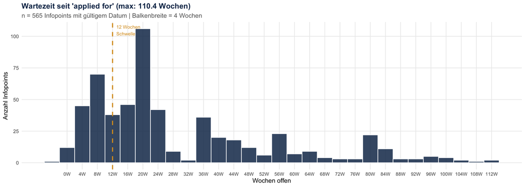

### 3.4 Übersicht: “Open”

**Gesamtanzahl Infopoints mit Status “open”:** 1605 (31.6%)

**Davon ohne Datum in “Creation time”:** 0 (0%)

**Davon mit Datum in “Creation time”:** 1605 (100%)

**Offene 'Open' Infopoints nach Wartezeit**

| Schwellenwert | Anzahl Infopoints | Anzahl Infopoints % |
| --- | --- | --- |
| < 4 Wochen | 16 | 1 |
| 4–8 Wochen | 13 | 0.8 |
| 8–12 Wochen | 11 | 0.7 |
| > 12 Wochen | 1565 | 97.5 |

### 3.5 Aufschlüsselung nach Projekt

**Open Infopoints nach Projekt und Wartezeit**

| Bau_Planung | Planned by | PB | Total open | Total open % | Kein Datum | Kein Datum % | < 4 Wochen | < 4 Wochen % | 4–8 Wochen | 4–8 Wochen % | 8–12 Wochen | 8–12 Wochen % | > 12 Wochen | > 12 Wochen % |
| --- | --- | --- | --- | --- | --- | --- | --- | --- | --- | --- | --- | --- | --- | --- |
| Bau fertig | 3071601, Mannersdorf am Leithagebirge | ZEIB | 100 | 100 | 0 | 0 | 0 | 0 | 1 | 1 | 0 | 0 | 99 | 99 |
| Bau fertig | 40818, Neumarkt im Hausruckkreis | GWK | 93 | 100 | 0 | 0 | 0 | 0 | 0 | 0 | 0 | 0 | 93 | 100 |
| Bau fertig | 4130901, Haslach an der Mühl | GWK | 84 | 100 | 0 | 0 | 0 | 0 | 0 | 0 | 0 | 0 | 84 | 100 |
| Bau fertig | 3061801, Kottingbrunn | ZEIB | 74 | 100 | 0 | 0 | 0 | 0 | 0 | 0 | 0 | 0 | 74 | 100 |
| Bau fertig | 40201001, Steyr_1 | KPP | 67 | 100 | 0 | 0 | 0 | 0 | 0 | 0 | 0 | 0 | 67 | 100 |
| Bau fertig | 4140201, Andorf | IKW | 60 | 100 | 0 | 0 | 0 | 0 | 0 | 0 | 0 | 0 | 60 | 100 |
| Bau fertig | 3191801, Kirchberg an der Pielach | ZEIB | 50 | 100 | 0 | 0 | 0 | 0 | 0 | 0 | 0 | 0 | 50 | 100 |
| Bau fertig | 3101501, Hadres | IKW | 49 | 100 | 0 | 0 | 0 | 0 | 0 | 0 | 0 | 0 | 49 | 100 |
| Bau fertig | 2041901, Maria Wörth | DPB | 48 | 100 | 0 | 0 | 0 | 0 | 0 | 0 | 0 | 0 | 48 | 100 |
| Bau fertig | 4182001, Stadl-Paura | KPP | 40 | 100 | 0 | 0 | 0 | 0 | 0 | 0 | 0 | 0 | 40 | 100 |

[output cut: 58 more lines]

⬇ Tabelle (CSV) ⬇ Rohdaten (CSV)

### 3.6 Histogramm: Wartezeit seit “open”

Maximaler Wert: **116.4 Wochen** (815 Tage).

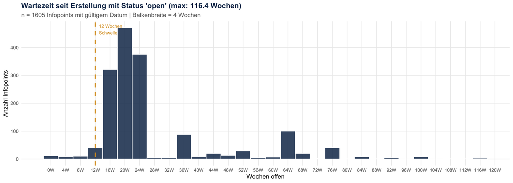

⬇ Tabelle (CSV) ⬇ Rohdaten (CSV)

**Kapitel 4: Bau/Planung-Kontext**

Dieses Kapitel analysiert Datenqualitätsprobleme **im Kontext des Bau/Planung-Status** der jeweiligen Projekte. Issues in Projekten mit Status **“Bau fertig”** sind dringlicher als solche in Projekten, die noch in Planung sind.

### 4.1 Überblick: Infopoints nach Bau/Planung-Status

**Infopoints nach Bau/Planung-Status**

| Bau_Planung | Total | Total % | Ohne Status | Ohne Status % | Built = Yes | Built = Yes % | Built = No | Built = No % | Payment = Yes | Payment = Yes % | Applied for | Applied for % | No response | No response % |
| --- | --- | --- | --- | --- | --- | --- | --- | --- | --- | --- | --- | --- | --- | --- |
| Bau fertig | 1585 | 100 | 5 | 0.3 | 947 | 59.7 | 276 | 17.4 | 156 | 9.8 | 64 | 4 | 99 | 6.2 |
| Planung | 525 | 100 | 0 | 0 | 3 | 0.6 | 305 | 58.1 | 227 | 43.2 | 172 | 32.8 | 46 | 8.8 |
| im Bau | 2971 | 100 | 11 | 0.4 | 734 | 24.7 | 933 | 31.4 | 309 | 10.4 | 500 | 16.8 | 179 | 6 |

⬇ Tabelle (CSV) ⬇ Rohdaten (CSV)

### 4.2 Kritische Issues nach Bau/Planung-Status

#### 4.2.1 Gebaut, aber Status ≠ receive — nach Bau/Planung

**Gebaut & Status ≠ receive: nach Bau/Planung-Status**

| Bau_Planung | Anzahl | Projekte | % von Gesamt |
| --- | --- | --- | --- |
| Bau fertig | 703 | 29 | 13.8 |
| im Bau | 318 | 29 | 6.3 |
| Planung | 3 | 1 | 0.1 |

⬇ Tabelle (CSV) ⬇ Rohdaten (CSV)

#### 4.2.2 Ohne Status-Eintrag — nach Bau/Planung

**Ohne Status-Eintrag: nach Bau/Planung-Status**

| Bau_Planung | Anzahl | Projekte | % von Gesamt |
| --- | --- | --- | --- |
| im Bau | 11 | 5 | 0.2 |
| Bau fertig | 5 | 3 | 0.1 |

⬇ Tabelle (CSV) ⬇ Rohdaten (CSV)

#### 4.2.3 Payment = Yes, Abgeltung nicht qualifiziert — nach Bau/Planung

**Offene Abgeltungen (nicht qualifiziert): nach Bau/Planung-Status**

| Bau_Planung | Anzahl offen | davon gebaut, kein receive | davon nicht gebaut | Projekte | % von Payment=Yes |
| --- | --- | --- | --- | --- | --- |
| Planung | 223 | 0 | 195 | 11 | 32.2 |
| im Bau | 161 | 20 | 88 | 27 | 23.3 |
| Bau fertig | 63 | 24 | 39 | 8 | 9.1 |

⬇ Tabelle (CSV) ⬇ Rohdaten (CSV)

**Kapitel 5: Gebaut ohne Leitungsrecht**

Infopoints mit `Built = Yes` **und** `Status ≠ receive` (fehlender Status zählt hier als “≠ receive”) — die physische Infrastruktur ist vorhanden, das Leitungsrecht aber noch nicht gesichert. Basis: alle aktiven, nicht-stornierten Infopoints (5081), gefiltert auf `Built = Yes`; davon ausgeschlossen sind nur Infopoints mit `Status = receive`.

**Warning⚠️ Gebaut ohne gesichertes Leitungsrecht**

**1024 Infopoints** (20.2% aller aktiven) sind gebaut, haben aber noch keinen `receive`-Status.

### 5.1 Nach Status

**Gebaut ohne LR — nach Status**

| Status | Total | % von Gesamt |
| --- | --- | --- |
| open | 791 | 77.2 |
| no response | 120 | 11.7 |
| applied for | 95 | 9.3 |
| rejected | 17 | 1.7 |
| NA / leer | 1 | 0.1 |

⬇ Tabelle (CSV) ⬇ Rohdaten (CSV)

### 5.2 Nach FeederDrop Level

**Gebaut ohne LR — nach FeederDrop Level**

| FeederDrop Level | Total | % von Gesamt |
| --- | --- | --- |
| Drop Level | 795 | 77.6 |
| Feeder Level | 229 | 22.4 |

⬇ Tabelle (CSV) ⬇ Rohdaten (CSV)

### 5.3 Nach Bau/Planung-Phase

**Gebaut ohne LR — nach Bau/Planung-Phase**

| Bau_Planung | Total | Projekte | % von Gesamt |
| --- | --- | --- | --- |
| Bau fertig | 703 | 29 | 68.7 |
| im Bau | 318 | 29 | 31.1 |
| Planung | 3 | 1 | 0.3 |

⬇ Tabelle (CSV) ⬇ Rohdaten (CSV)

### 5.4 Kreuztabelle: Status × FeederDrop Level

**Gebaut ohne LR — Status × FeederDrop Level**

| Status | Total | Total % | Drop Level | Drop Level % | Feeder Level | Feeder Level % |
| --- | --- | --- | --- | --- | --- | --- |
| open | 791 | 100 | 626 | 79.1 | 165 | 20.9 |
| no response | 120 | 100 | 83 | 69.2 | 37 | 30.8 |
| applied for | 95 | 100 | 72 | 75.8 | 23 | 24.2 |
| rejected | 17 | 100 | 13 | 76.5 | 4 | 23.5 |
| NA / leer | 1 | 100 | 1 | 100 | 0 | 0 |

⬇ Tabelle (CSV) ⬇ Rohdaten (CSV)

### 5.5 Aufschlüsselung nach Projekt

**Gebaut ohne LR — nach Projekt und FeederDrop Level**

| Planned by | PB | Bau_Planung | Drop Level | Feeder Level | NA / leer | Total | % von Gesamt |
| --- | --- | --- | --- | --- | --- | --- | --- |
| 40818, Neumarkt im Hausruckkreis | GWK | Bau fertig | 52 | 36 | 0 | 88 | 8.6 |
| 4130901, Haslach an der Mühl | GWK | Bau fertig | 65 | 18 | 0 | 83 | 8.1 |
| 3071601, Mannersdorf am Leithagebirge | ZEIB | Bau fertig | 53 | 27 | 0 | 80 | 7.8 |
| 4173801, Schwanenstadt | KPP | Bau fertig | 50 | 27 | 0 | 77 | 7.5 |
| 3060701, Ebreichsdorf | ZEIB | im Bau | 56 | 5 | 0 | 61 | 6 |
| 4140201, Andorf | IKW | Bau fertig | 47 | 8 | 0 | 55 | 5.4 |
| 6066901, Seiersberg-Pirka 1 (West) | Umwelt & Bau | im Bau | 46 | 3 | 0 | 49 | 4.8 |
| 2041901, Maria Wörth | DPB | Bau fertig | 31 | 10 | 0 | 41 | 4 |
| 3191801, Kirchberg an der Pielach | ZEIB | Bau fertig | 36 | 5 | 0 | 41 | 4 |
| 3061801, Kottingbrunn | ZEIB | Bau fertig | 27 | 8 | 0 | 35 | 3.4 |

[output cut: 49 more lines]

⬇ Tabelle (CSV) ⬇ Rohdaten (CSV)

**Kapitel 6: LR im Zeitverlauf**

Entwicklung der Infopoints je Status über die Zeit (wöchentlich), basierend auf der Zusammenfassung in `LR-Statusentwicklung_piha_neu.xlsx` (Tabellenblatt `Statusentwicklung`). On-hold Projekte wurden nicht einbezogen.

### 6.1 Entwicklung nach Status

[interactive chart not shown]

### 6.2 Rohdaten

**LR-Statusentwicklung je Kalenderwoche**

| kw | Abgelehnt | Angesucht | Erhalten | Offen | Storniert | No_Response |
| --- | --- | --- | --- | --- | --- | --- |
| KW 06 | 359 | 950 | 1224 | 659 | 698 | 0 |
| KW 07 | 360 | 948 | 1259 | 638 | 728 | 0 |
| KW 08 | 375 | 945 | 1264 | 773 | 724 | 0 |
| KW 09 | 321 | 918 | 1288 | 1015 | 817 | 0 |
| KW 11 | 330 | 900 | 1322 | 1424 | 823 | 0 |
| KW 12 | 338 | 909 | 1351 | 1452 | 828 | 0 |
| KW 13 | 346 | 936 | 1362 | 1580 | 848 | 0 |
| KW 14 | 360 | 920 | 1383 | 1907 | 943 | 0 |
| KW 15 | 361 | 892 | 1424 | 1839 | 1130 | 0 |
| KW 16 | 398 | 1016 | 1444 | 1956 | 1211 | 0 |

[output cut: 15 more lines]

⬇ Tabelle (CSV) ⬇ Rohdaten (CSV)

**Kapitel 7: Projektseiten**

Projekt auswählen, um die wichtigsten Kennzahlen ausschließlich für dieses Projekt zu sehen: Status-Verteilung, FeederDrop Level, Built-Status und die Zeitkomponente (applied for / open).

Projekt suchen

Klicken zum Auswählen

Baulos

FeederDrop Level

Drop Level Feeder Level NA / leer

PCM Planungsbüro (PB) Projektstatus

Bitte mindestens ein Projekt oben auswählen.

**Note**

Alle Kacheln beziehen sich auf **5081 aktive, nicht stornierte Infopoints** (dieselbe Basis wie im restlichen Bericht). Bei Auswahl mehrerer Projekte werden die Zahlen über alle ausgewählten Projekte aufsummiert.

**DQ**

Datenqualität

226

HP behind fehlt (4.4% ohne storniert)

90

Alle 3 Katasterfelder fehlen (1.8% ohne storniert)

**Informationen/Quellen**

### Metadaten

| Feld | Wert |
| --- | --- |
| Version | 1.1 |
| Erstellt am | 2026-08-13 |
| Datenstand (Infopoints) | 2026-08-10 |
| Infopoints-Datei (privates LR) | Customized_InfoLocations_privates_LR_2026_08_10.csv |
| Infopoints-Datei (MDU) | Customized_InfoLocations_MDU_Durchleitungen_2026_08_12.csv |
| Infopoints-Datei (SN) | Customized_InfoLocations_SN_2026_08_12.csv |
| Projektliste-Datei | Projektzuordnung PB PCM Status_aktuell.xlsx |
| Baulos-Datei (privates LR) | baulos_lookup_2026_08_05.csv |
| Baulos-Datei (MDU) | baulos_lookup_mdu_2026_08_12.csv |
| Baulos-Datei (SN) | baulos_lookup_sn_2026_08_12.csv |

### Aktive Projekte gemäß Pias/PCM Liste (siehe Projektliste-Datei)

Projekte, die im Bericht berücksichtigt werden (ohne “on hold”).

| Gemeinden | PB | LR-Akquise | PB_HP_dahinter | PCM | Bau/Planung | ende_bau_passiv_plan | FC2_TB_abgeschlossen |
| --- | --- | --- | --- | --- | --- | --- | --- |
| 3060701, Ebreichsdorf | ZEIB | ZEIB | ZEIB | Cosi | im Bau | 2027-05-31T00:00:00Z | NA |
| 20201001, Villach - Warmbad | CCE | Infrasales | CCE | Conny | im Bau | 2027-06-30T00:00:00Z | NA |
| 20201002, Villach - Innere Stadt | CCE | Infrasales | CCE | Conny | im Bau | 2027-06-30T00:00:00Z | NA |
| 20201003, Villach - Untere Fellach | CCE | Infrasales | CCE | Conny | im Bau | 2027-06-30T00:00:00Z | NA |
| 20201004, Villach - Bahnhofsviertel - Seebach | Fionis | Fionis | Fionis | Conny | im Bau | 2027-06-30T00:00:00Z | NA |
| 20201005, Villach - Auen | CCE | Infrasales | CCE | Conny | im Bau | 2026-11-30T00:00:00Z | NA |
| 2041901, Maria Wörth | DPB | DPB | DPB | Marian | Bau fertig | 2026-06-15T00:00:00Z | x |
| 20515, Liebenfels | Kastner | Kastner | Kastner | Cosi | Planung | NA | NA |
| 20527, St. Veit an der Glan | GisQuadrat | GisQuadrat | GisQuadrat | Marian | Planung | NA | NA |
| 20630, Radenthein | GisQuadrat | GisQuadrat | GisQuadrat | Marian | Planung | NA | NA |

[output cut: 87 more lines]

### Projekte “On Hold”

| Gemeinden | PB | LR-Akquise | PB_HP_dahinter | PCM | Bau/Planung | ende_bau_passiv_plan | FC2_TB_abgeschlossen |
| --- | --- | --- | --- | --- | --- | --- | --- |
| 62105, Breitenau am Hochlantsch | on hold | on hold | NA | NA | on hold | NA | NA |
| 1031801, Wimpassing an der Leitha | on hold | on hold | NA | NA | on hold | NA | NA |
| 20402, Ebenthal in Kärnten | on hold | on hold | NA | NA | on hold | NA | NA |
| 20643, Lurnfeld | on hold | on hold | NA | NA | on hold | NA | NA |
| 3062601, Pottendorf | on hold | on hold | NA | NA | on hold | NA | NA |
| 3063701, Teesdorf | on hold | on hold | NA | NA | on hold | NA | NA |
| 30838, Matzen-Raggendorf | on hold | on hold | NA | NA | on hold | NA | NA |
| 31018, Haugsdorf | on hold | on hold | NA | NA | on hold | NA | NA |
| 31235, Gerasdorf bei Wien | on hold | on hold | NA | NA | on hold | NA | NA |
| 31621, Herrnbaumgarten | on hold | on hold | NA | NA | on hold | NA | NA |

[output cut: 18 more lines]